# PlotWd

Esta función permite describir en forma gráfica las caracterísicas del viento en intensidad y dirección. Los gráficos que se pueden obtener a partir de esta fución son: *histogramas*, *rosas de vientos*, *ajustes a diferentes distribuciones*, *series de tiempos*, *turbulencia*, *correlaciones entre diferentes anemómetros*.

Los parámetros que uitiliza la función son:

- **data** objeto de clase Windata,
- **ane** distiguen el anemómetro a ser analizado. Por default analiza todos los anemómetros.
- **var** variable que se quiere estudiar. Por default se utiliza la media de la velocidad del viento.
- **type** indica que tipo de gráfico se requiere. Los posibles gráficos son los expresados anteriormente.
- **by** permite hacer comparaciones para distintos intervalos de tiempos.Las opciones de intervalos son *hour*, *day* y *month*.
- **since** esta opción permite indicar desde que fecha se requiere el análisis.
- **to** esta opción permite indicar hasta que fecha se requier el análisis
- **bindwith** parámetro para indicar el ancho del bin.

Las variables admitidas para el gráfico rosa de viento son *velocidad media*, *mímima* o *máxima*, y *frecuencia*. Para los otros tipos de gráficos la única variable admitida es velocidad media.  
El gráfico fit compara los diferentes ajustes meidante las ditribuciones *Weibull*, *Gamma* y *Lognormal*.  
El parámetro **by** es utilizado en lo tipos de gráficos *histogramas*, *rosas de vientos* y *perfiles*.  
**Bindwith** es utilizado solamente en los gráficos *histograma* y *fit*

**A continuación se presentan diferentes ejemplos de posibles gráficos de la función:**

```r
library("WindResource")
data(wdOlavarria)
```

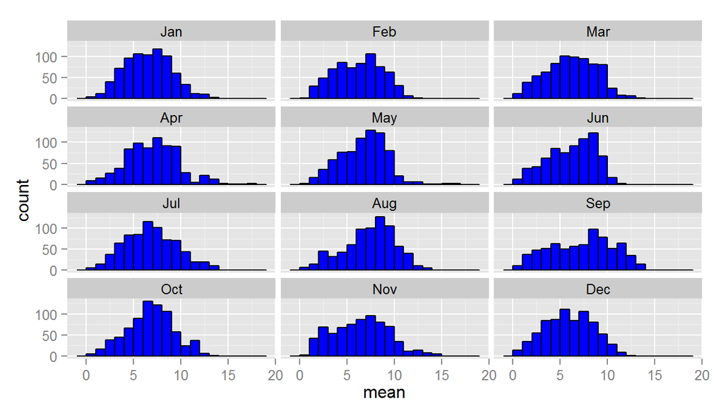

```r
plotWD (data=wdOlavarria, var="mean", type="histogram", by="month")
```

Gráfico 1. Comparación de la velocidad media del viento de cada mes mediante histogramas.

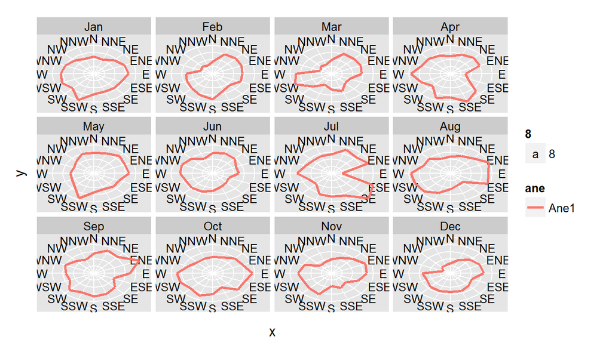

```r
plotWD (data=wdOlavarria, var="mean", type="rose", by="month")
```

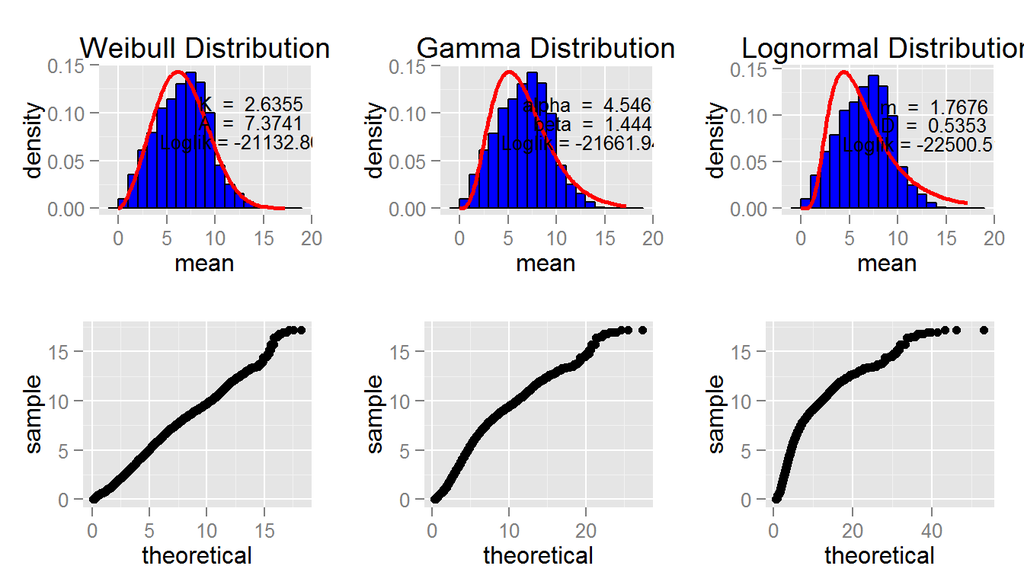

```r
plotWD (data=wdOlavarria, type="fit")
```